# Инд. проект, этап 2

Преподаватель Кулябов Дмитрий Сергеевич, д.ф.-м.н, профессор кафедры теории вероятностей и кибербезопасности

Азарцова Вероника Валерьевна

1132246751@rudn.ru

Российский университет дружбы народов

2026-03-20

# Вводная часть

## Докладчик

- Азарцова Вероника Валерьевна
- Студентка группы НКАбд-01-24
- Факультета физико-математических и естественных наук
- Российский университет дружбы народов им. П. Лумумбы
- 1132246751@rudn.ru
- https://vvazarcova.github.io/ru/

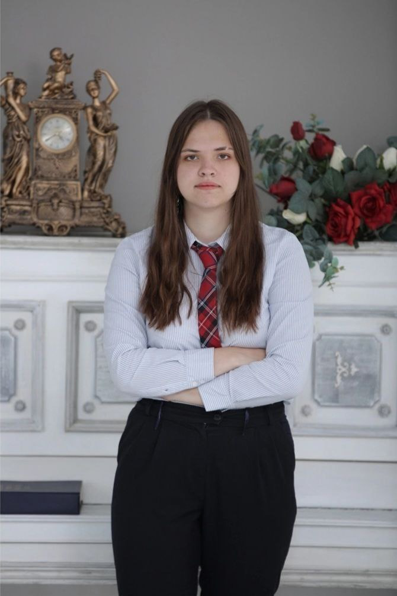

## Теоретическое введение

Damn Vulnerable Web Application (DVWA) - намеренно уязвимое веб-приложение, созданное для профессионалов и студентов, обучающихся в области безопасности, разработчиков и команд dev-ops, чтобы они могли использовать свои инструменты тестирования, усилить конфигурации и убедиться, что защита ужесточена.

# Выполнение этапа

## Настройка DVWA и датабазы

1. Скачиваю репозиторий DVWA с помощью git clone в каталоге со всеми файлами localhost (рис. 1).

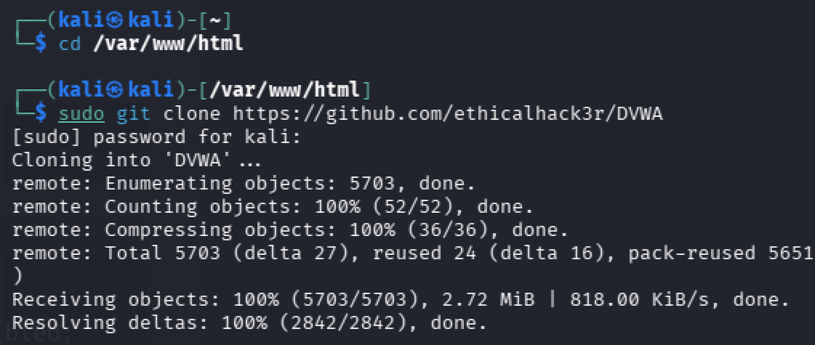

Рисунок 1: Скачивание репозитория

## Настройка DVWA и датабазы

2. Выдаю папке DVWA все разрешения с помощью команды sudo chmod -R 777 DVWA, и затем перехожу в её папку конфиг, где копирую файл конфигурации на всякий случай, а затем с помощью nano меняю в нем имя пользователя и пароль на следующее: рис. 2.

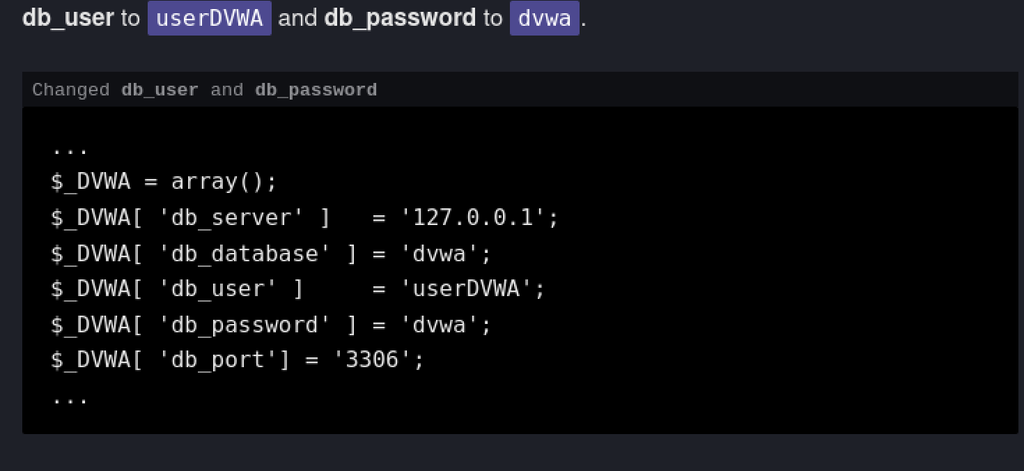

Рисунок 2: Смена имя пользователя и пароля

## Настройка DVWA и датабазы

3. Запускаю сервис mysql и проверяю его статус, чтобы убедиться, что он запущен (рис. 3).

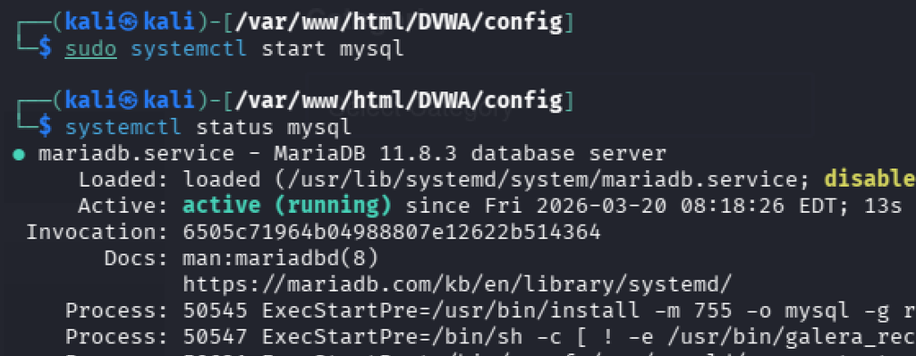

Рисунок 3: Сервис mysql

## Настройка DVWA и датабазы

4. Логинюсь в систему для менеджмента датабаз MariaDB, которая уже стоит на системе Kali Linux (рис. 4).

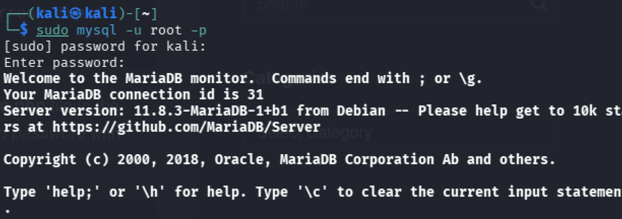

Рисунок 4: Вход в MariaDB

## Настройка DVWA и датабазы

5. Создаю нового пользователя и задаю ему пароль, используя имя и пароль которые я задала в config.inc.php в шаге 2, а так же выдаю ему полные полномочия над датабазой dvwa (рис. 5).

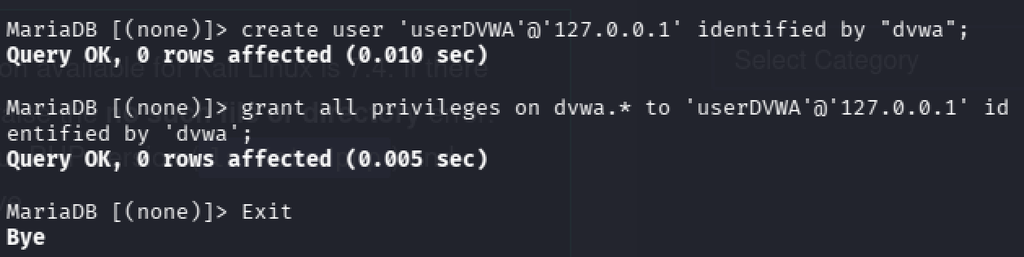

Рисунок 5: Создание пользователя в MariaDB и выдача привелегий

## Настройка Apache

1. Перехожу в каталог апачи и использую nano чтобы изменить файл с настройками (рис. 6).

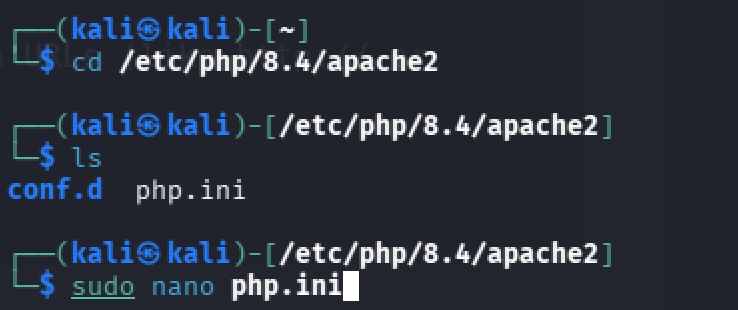

Рисунок 6: Каталог апачи и nano

## Настройка Apache

2. Меняю конфигурацию allow_url_fopen и allow_url_include на On, сохраняю файл и возвращаюсь в терминал (рис. 7).

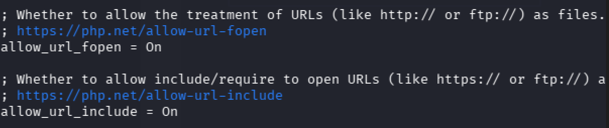

Рисунок 7: Настройка конфигурации апачи

## Настройка Apache

3. Запускаю апачи и проверяю его статус (всё работает) (рис. 8).

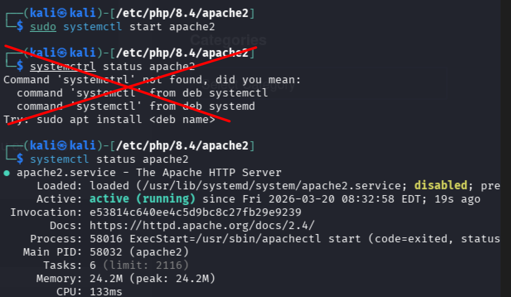

Рисунок 8: Запуск апачи

## Настройка Apache

Теперь просто ввожу http://127.0.0.1/DVWA/setup.php в мой браузер (Мозилла) и ввожу имя пользователя и пароль (по умолчанию: admin, password), и после этого сразу же загружается страница моего сайта DVWA (рис. 9).

[figure not shown]

Все задачи этапа выполнены.

## Контрольный вопрос

Контрольный вопрос к данному этапу:

Можно ли ставить DVWA на свой публичный веб сервер?

Ответ: Нет, нельзя, т.к. оно специально разработано с огромным количеством уязвимостей, что ставит в опасность сервер. Поэтому мы устанавливаем его и работаем с ним на виртуальной машине.

## Заключение

Если вам понравилось - посмотрите остальные мои презентации!

Rutube: vvazarcova